# Mental Health in Tech

Ilia Ozhmegov

January 6, 2021

## Introduction

Mental Health is a very important matter that became even more since COVID as the majority of urban people have to work from home since there is no difference between working place and relaxing place. And as a result it affect mental health in one or another way.

Customer placed the following questions to me:

- What is the most important factors to define the necessity of mental treatment?
- Is it possible to build any ML model based on those feature to evaluate the risk of mental health problems?
- What accuracy would be of a model if it is possible?

## Data and Preprocessing (cleaning, imputing missing values)

```r
library(tidyverse)
library(lubridate)
library(magrittr)
library(stringdist)
library(recipes)


df = read.csv(file=here::here("data/survey.csv"))
```

| Feature name | Description |
| --- | --- |
| Timestamp | - |
| Age | - |
| Gender | - |
| Country | - |
| State | (only for US) |
| Self employed | Are you self-employed? |
| Family history | Family history of mental illness |
| Work interfere | Is mental health condition affects work? |
| No employees | The number of employees in your company or organization |
| Remote work | Having remote work (outside of an office) at least 50% of the time |
| Tech company | The employer is primarily a tech company/organization |
| Benefits | Providing mental health benefits by the employer |
| Care options: | Providing options for mental health care by the employer |
| Wellness program | Discussion about mental health as part of an employee wellness program by the employes |
| Seek help | Providing resources by the employer to learn more about mental health issues and how to seek help |
| Anonymity | Protecting anonymity if you choose to take advantage of mental health or substance abuse treatment resources |
| Leave | How easy is it for you to take medical leave for a mental health condition? |
| Mental-health consequence: | Having negative consequences caused by discussing a mental health issue with your employer |
| Phys-health consequence | Having negative consequences caused by discussing a physical health issue with your employer |
| Coworkers | Would you be willing to discuss a mental health issue with your coworkers? |
| Supervisor | Would you be willing to discuss a mental health issue with your direct supervisor(s)? |
| Mental health interview: | Would you bring up a mental health issue with a potential employer in an interview? |
| Phys health interview | Would you bring up a physical health issue with a potential employer in an interview? |
| Mental vs Physical | Do you feel that your employer takes mental health as seriously as physical health? |
| Obs consequence | Have you heard of or observed negative consequences for coworkers with mental health conditions in your workplace? |
| Comments | Any additional notes or comments |
| Treatment | Is treatment for a mental health condition was? |

### Data Frame structure

```r
df %>% str(max.level=2)
```

```
## 'data.frame':    1259 obs. of  27 variables:
##  $ Timestamp                : Factor w/ 1246 levels "2014-08-27 11:29:31",..: 1 2 3 4 5 6 7 8 9 10 ...
##  $ Age                      : num  37 44 32 31 31 33 35 39 42 23 ...
##  $ Gender                   : Factor w/ 49 levels "A little about you",..: 16 24 30 30 30 30 16 24 16 30 ...
##  $ Country                  : Factor w/ 48 levels "Australia","Austria",..: 46 46 8 45 46 46 46 8 46 8 ...
##  $ state                    : Factor w/ 45 levels "AL","AZ","CA",..: 11 12 NA NA 38 37 19 NA 11 NA ...
##  $ self_employed            : Factor w/ 2 levels "No","Yes": NA NA NA NA NA NA NA NA NA NA ...
##  $ family_history           : Factor w/ 2 levels "No","Yes": 1 1 1 2 1 2 2 1 2 1 ...
##  $ treatment                : Factor w/ 2 levels "No","Yes": 2 1 1 2 1 1 2 1 2 1 ...
##  $ work_interfere           : Factor w/ 4 levels "Never","Often",..: 2 3 3 2 1 4 4 1 4 1 ...
##  $ no_employees             : Factor w/ 6 levels "1-5","100-500",..: 5 6 5 3 2 5 1 1 2 3 ...
##  $ remote_work              : Factor w/ 2 levels "No","Yes": 1 1 1 1 2 1 2 2 1 1 ...
##  $ tech_company             : Factor w/ 2 levels "No","Yes": 2 1 2 2 2 2 2 2 2 2 ...
##  $ benefits                 : Factor w/ 3 levels "Don't know","No",..: 3 1 2 2 3 3 2 2 3 1 ...
##  $ care_options             : Factor w/ 3 levels "No","Not sure",..: 2 1 1 3 1 2 1 3 3 1 ...
##  $ wellness_program         : Factor w/ 3 levels "Don't know","No",..: 2 1 2 2 1 2 2 2 2 1 ...
##  $ seek_help                : Factor w/ 3 levels "Don't know","No",..: 3 1 2 2 1 1 2 2 2 1 ...
##  $ anonymity                : Factor w/ 3 levels "Don't know","No",..: 3 1 1 2 1 1 2 3 2 1 ...
##  $ leave                    : Factor w/ 5 levels "Don't know","Somewhat difficult",..: 3 1 2 2 1 1 2 1 4 1 ...
##  $ mental_health_consequence: Factor w/ 3 levels "Maybe","No","Yes": 2 1 2 3 2 2 1 2 1 2 ...
##  $ phys_health_consequence  : Factor w/ 3 levels "Maybe","No","Yes": 2 2 2 3 2 2 1 2 2 2 ...
##  $ coworkers                : Factor w/ 3 levels "No","Some of them",..: 2 1 3 2 2 3 2 1 3 3 ...
##  $ supervisor               : Factor w/ 3 levels "No","Some of them",..: 3 1 3 1 3 3 1 1 3 3 ...
##  $ mental_health_interview  : Factor w/ 3 levels "Maybe","No","Yes": 2 2 3 1 3 2 2 2 2 1 ...
##  $ phys_health_interview    : Factor w/ 3 levels "Maybe","No","Yes": 1 2 3 1 3 1 2 2 1 1 ...
##  $ mental_vs_physical       : Factor w/ 3 levels "Don't know","No",..: 3 1 2 2 1 1 1 2 2 3 ...
##  $ obs_consequence          : Factor w/ 2 levels "No","Yes": 1 1 1 2 1 1 1 1 1 1 ...
##  $ comments                 : Factor w/ 160 levels " ","-","(yes but the situation was unusual and involved a change in leadership at a very high level in the organization"| __truncated__,..: NA NA NA NA NA NA NA NA NA NA ...
```

### Preprocessing

As you could notice feature names are differ, so we will make them in the same format.

```r
df = df %>%
    rename_all(function(.name){ .name %>% tolower() }) %>%
    mutate(timestamp = as_datetime(timestamp))

df %>% str(max.level=2)
```

```
## 'data.frame':    1259 obs. of  27 variables:
##  $ timestamp                : POSIXct, format: "2014-08-27 11:29:31" "2014-08-27 11:29:37" ...
##  $ age                      : num  37 44 32 31 31 33 35 39 42 23 ...
##  $ gender                   : Factor w/ 49 levels "A little about you",..: 16 24 30 30 30 30 16 24 16 30 ...
##  $ country                  : Factor w/ 48 levels "Australia","Austria",..: 46 46 8 45 46 46 46 8 46 8 ...
##  $ state                    : Factor w/ 45 levels "AL","AZ","CA",..: 11 12 NA NA 38 37 19 NA 11 NA ...
##  $ self_employed            : Factor w/ 2 levels "No","Yes": NA NA NA NA NA NA NA NA NA NA ...
##  $ family_history           : Factor w/ 2 levels "No","Yes": 1 1 1 2 1 2 2 1 2 1 ...
##  $ treatment                : Factor w/ 2 levels "No","Yes": 2 1 1 2 1 1 2 1 2 1 ...
##  $ work_interfere           : Factor w/ 4 levels "Never","Often",..: 2 3 3 2 1 4 4 1 4 1 ...
##  $ no_employees             : Factor w/ 6 levels "1-5","100-500",..: 5 6 5 3 2 5 1 1 2 3 ...
##  $ remote_work              : Factor w/ 2 levels "No","Yes": 1 1 1 1 2 1 2 2 1 1 ...
##  $ tech_company             : Factor w/ 2 levels "No","Yes": 2 1 2 2 2 2 2 2 2 2 ...
##  $ benefits                 : Factor w/ 3 levels "Don't know","No",..: 3 1 2 2 3 3 2 2 3 1 ...
##  $ care_options             : Factor w/ 3 levels "No","Not sure",..: 2 1 1 3 1 2 1 3 3 1 ...
##  $ wellness_program         : Factor w/ 3 levels "Don't know","No",..: 2 1 2 2 1 2 2 2 2 1 ...
##  $ seek_help                : Factor w/ 3 levels "Don't know","No",..: 3 1 2 2 1 1 2 2 2 1 ...
##  $ anonymity                : Factor w/ 3 levels "Don't know","No",..: 3 1 1 2 1 1 2 3 2 1 ...
##  $ leave                    : Factor w/ 5 levels "Don't know","Somewhat difficult",..: 3 1 2 2 1 1 2 1 4 1 ...
##  $ mental_health_consequence: Factor w/ 3 levels "Maybe","No","Yes": 2 1 2 3 2 2 1 2 1 2 ...
##  $ phys_health_consequence  : Factor w/ 3 levels "Maybe","No","Yes": 2 2 2 3 2 2 1 2 2 2 ...
##  $ coworkers                : Factor w/ 3 levels "No","Some of them",..: 2 1 3 2 2 3 2 1 3 3 ...
##  $ supervisor               : Factor w/ 3 levels "No","Some of them",..: 3 1 3 1 3 3 1 1 3 3 ...
##  $ mental_health_interview  : Factor w/ 3 levels "Maybe","No","Yes": 2 2 3 1 3 2 2 2 2 1 ...
##  $ phys_health_interview    : Factor w/ 3 levels "Maybe","No","Yes": 1 2 3 1 3 1 2 2 1 1 ...
##  $ mental_vs_physical       : Factor w/ 3 levels "Don't know","No",..: 3 1 2 2 1 1 1 2 2 3 ...
##  $ obs_consequence          : Factor w/ 2 levels "No","Yes": 1 1 1 2 1 1 1 1 1 1 ...
##  $ comments                 : Factor w/ 160 levels " ","-","(yes but the situation was unusual and involved a change in leadership at a very high level in the organization"| __truncated__,..: NA NA NA NA NA NA NA NA NA NA ...
```

#### Preprocessing: gender issue

There are some issues with variable `gender`.

```r
df %>%
    group_by(gender) %>%
    summarise(n = n(), .groups="drop") %>%
    arrange(desc(n)) %>%
    head(20)
```

```
## # A tibble: 20 x 2
##    gender                   n
##    <fct>                <int>
##  1 "Male"                 615
##  2 "male"                 206
##  3 "Female"               121
##  4 "M"                    116
##  5 "female"                62
##  6 "F"                     38
##  7 "m"                     34
##  8 "f"                     15
##  9 "Make"                   4
## 10 "Male "                  3
## 11 "Woman"                  3
## 12 "Cis Male"               2
## 13 "Female "                2
## 14 "Female (trans)"         2
## 15 "Man"                    2
## 16 "A little about you"     1
## 17 "Agender"                1
## 18 "All"                    1
## 19 "Androgyne"              1
## 20 "Cis Female"             1
```

So I solved this issue with the following approach:

```r
# TODO: transform gender to Male/Female/Other Format


normalize_gender <- function(input){
    input = tolower(input)
    gender_type = c("male", "female", "confusion")

    if(all(input == gender_type[1])) return(gender_type[1])
    if(all(input == gender_type[2])) return(gender_type[2])

    male_word_pool      = c("male", "man", "guy", "m")
    female_word_pool    = c("female", "woman", "girl", "f")
    confusing_word_pool = c("trans", "agender", "fluid", "queer", "binary", "na", "all", "p", "unsure")

    male_value   = min(stringdist::stringdist(input, male_word_pool,       "jaccard"))
    female_value = min(stringdist::stringdist(input, female_word_pool,     "jaccard"))
    confusion_value  = min(stringdist::stringdist(input, confusing_word_pool,  "jaccard"))

    i = which.min(c(male_value, female_value, confusion_value))

    return(gender_type[i])

}

df = df %>%
    mutate(gender = map(gender, normalize_gender),
           gender = unlist   (gender),
           gender = as.factor(gender))
```

Here I measured the distance between words with `jaccard` metric. It outputs the value between 0 and 1. The closer words the lesser value.

Now we have it in the following way

```r
df %>%
    group_by(gender) %>%
    summarise(n = n(), .groups="drop") %>%
    arrange(desc(n)) %>%
    head(20)
```

```
## # A tibble: 3 x 2
##   gender        n
##   <fct>     <int>
## 1 male        992
## 2 female      251
## 3 confusion    16
```

#### Preprocessing: age issue

There is some entries with wrong age. Some of them are negative and some of them are too big.

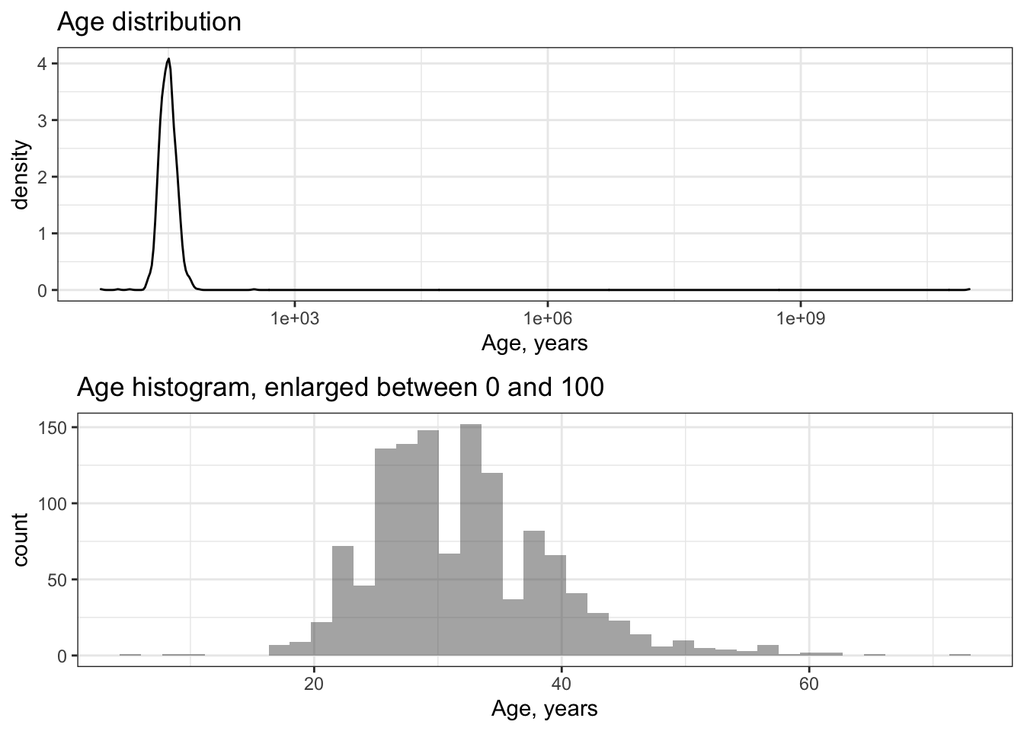

```r
p1 = df %>%
    ggplot(aes(age)) +
    geom_density() +
    scale_x_continuous(trans='log10') +
    ggtitle("Age distribution") +
    labs(x="Age, years") +
    theme_bw()


p2 = df %>%
    filter(age > 0) %>%
    filter(age < 100) %>%
    ggplot(aes(x=age)) +
      geom_histogram(alpha=0.5, position="identity", bins = 40) +
      theme_bw() +
      labs(x="Age, years") +
      ggtitle("Age histogram, enlarged between 0 and 100")

gridExtra::grid.arrange(p1, p2, nrow=2)
```

As the solution I just get rid of entries that outside of `[18, 100)` range

```r
# TODO: remove outlier entries by age

before = df %>% nrow()

df %<>%
    filter(age > 17) %>%
    filter(age < 100)

after = df %>% nrow()

cat("Were thrown", before - after, "entries\n")
```

```
## Were thrown 8 entries
```

#### Imputing: evaluate missing values

To evaluate the number of missing values per column the following approach will be used:

```r
df %>% glimpse()
```

```
## Rows: 1,251
## Columns: 27
## $ timestamp                 <dttm> 2014-08-27 11:29:31, 2014-08-27 11:29:37...
## $ age                       <dbl> 37, 44, 32, 31, 31, 33, 35, 39, 42, 23, 3...
## $ gender                    <fct> female, male, male, male, male, male, fem...
## $ country                   <fct> United States, United States, Canada, Uni...
## $ state                     <fct> IL, IN, NA, NA, TX, TN, MI, NA, IL, NA, O...
## $ self_employed             <fct> NA, NA, NA, NA, NA, NA, NA, NA, NA, NA, N...
## $ family_history            <fct> No, No, No, Yes, No, Yes, Yes, No, Yes, N...
## $ treatment                 <fct> Yes, No, No, Yes, No, No, Yes, No, Yes, N...
## $ work_interfere            <fct> Often, Rarely, Rarely, Often, Never, Some...
## $ no_employees              <fct> 6-25, More than 1000, 6-25, 26-100, 100-5...
## $ remote_work               <fct> No, No, No, No, Yes, No, Yes, Yes, No, No...
## $ tech_company              <fct> Yes, No, Yes, Yes, Yes, Yes, Yes, Yes, Ye...
## $ benefits                  <fct> Yes, Don't know, No, No, Yes, Yes, No, No...
## $ care_options              <fct> Not sure, No, No, Yes, No, Not sure, No, ...
## $ wellness_program          <fct> No, Don't know, No, No, Don't know, No, N...
## $ seek_help                 <fct> Yes, Don't know, No, No, Don't know, Don'...
## $ anonymity                 <fct> Yes, Don't know, Don't know, No, Don't kn...
## $ leave                     <fct> Somewhat easy, Don't know, Somewhat diffi...
## $ mental_health_consequence <fct> No, Maybe, No, Yes, No, No, Maybe, No, Ma...
## $ phys_health_consequence   <fct> No, No, No, Yes, No, No, Maybe, No, No, N...
## $ coworkers                 <fct> Some of them, No, Yes, Some of them, Some...
## $ supervisor                <fct> Yes, No, Yes, No, Yes, Yes, No, No, Yes, ...
## $ mental_health_interview   <fct> No, No, Yes, Maybe, Yes, No, No, No, No, ...
## $ phys_health_interview     <fct> Maybe, No, Yes, Maybe, Yes, Maybe, No, No...
## $ mental_vs_physical        <fct> Yes, Don't know, No, No, Don't know, Don'...
## $ obs_consequence           <fct> No, No, No, Yes, No, No, No, No, No, No, ...
## $ comments                  <fct> NA, NA, NA, NA, NA, NA, NA, NA, NA, NA, N...
```

```r
df %>% summarise_all(~ sum(is.na(.)))
```

```
##   timestamp age gender country state self_employed family_history treatment
## 1         0   0      0       0   513            18              0         0
##   work_interfere no_employees remote_work tech_company benefits care_options
## 1            262            0           0            0        0            0
##   wellness_program seek_help anonymity leave mental_health_consequence
## 1                0         0         0     0                         0
##   phys_health_consequence coworkers supervisor mental_health_interview
## 1                       0         0          0                       0
##   phys_health_interview mental_vs_physical obs_consequence comments
## 1                     0                  0               0     1090
```

```r
    df = df %>%
        select(-comments) %>%
        pmap(function(country, state, ...){
                 if(country != "United States") state = "None"

                 return(data.frame(country, state, ...))
          }) %>%
    bind_rows()  %>%
    mutate(state = as.character(state)) %>%
    mutate(state = as.factor   (state))

df$state  %>% levels() # now you can see "None"
```

```
##  [1] "AL"   "AZ"   "CA"   "CO"   "CT"   "DC"   "FL"   "GA"   "IA"   "ID"
## [11] "IL"   "IN"   "KS"   "KY"   "LA"   "MA"   "MD"   "ME"   "MI"   "MN"
## [21] "MO"   "MS"   "NC"   "NE"   "NH"   "NJ"   "NM"   "None" "NV"   "NY"
## [31] "OH"   "OK"   "OR"   "PA"   "RI"   "SC"   "SD"   "TN"   "TX"   "UT"
## [41] "VA"   "VT"   "WA"   "WI"   "WV"   "WY"
```

#### Imputing

It is important to mark that certain values for some variables used to be `NA`.

```r
check_NA <- function(value) ifelse(is.na(value), "yes", "no")

df = df %>%
    mutate(
           isNAstate          = check_NA(state),
           isNAself_employed  = check_NA(self_employed),
           isNAwork_interfere = check_NA(work_interfere),

           isNAstate          = as.factor(isNAstate),
           isNAself_employed  = as.factor(isNAself_employed),
           isNAwork_interfere = as.factor(isNAwork_interfere),
    )

df %>% glimpse()
```

```
## Rows: 1,251
## Columns: 29
## $ country                   <fct> United States, United States, Canada, Uni...
## $ state                     <fct> IL, IN, None, None, TX, TN, MI, None, IL,...
## $ timestamp                 <dttm> 2014-08-27 11:29:31, 2014-08-27 11:29:37...
## $ age                       <dbl> 37, 44, 32, 31, 31, 33, 35, 39, 42, 23, 3...
## $ gender                    <fct> female, male, male, male, male, male, fem...
## $ self_employed             <fct> NA, NA, NA, NA, NA, NA, NA, NA, NA, NA, N...
## $ family_history            <fct> No, No, No, Yes, No, Yes, Yes, No, Yes, N...
## $ treatment                 <fct> Yes, No, No, Yes, No, No, Yes, No, Yes, N...
## $ work_interfere            <fct> Often, Rarely, Rarely, Often, Never, Some...
## $ no_employees              <fct> 6-25, More than 1000, 6-25, 26-100, 100-5...
## $ remote_work               <fct> No, No, No, No, Yes, No, Yes, Yes, No, No...
## $ tech_company              <fct> Yes, No, Yes, Yes, Yes, Yes, Yes, Yes, Ye...
## $ benefits                  <fct> Yes, Don't know, No, No, Yes, Yes, No, No...
```

[output cut: 16 more lines]

Now you can see dummy variables that start with `isNA`. Perhaps it would be better to name those `wasNA`.

Now, imputation step. Here will be used k-nn approach to fill NA wit something sane.

```r
impute_recipe  <- df %>%
    recipe(treatment ~ .) %>%
    step_knnimpute(all_predictors(), neighbors = 3)

imputed_df = impute_recipe %>%
    prep() %>%
    juice()

imputed_df %>%
    summarise_all(~ sum(is.na(.))) %>%
    sum() # The common number of NAs across the whole df
```

```
## [1] 0
```

```r
df = imputed_df

df %>% glimpse()
```

```
## Rows: 1,251
## Columns: 29
## $ country                   <fct> United States, United States, Canada, Uni...
## $ state                     <fct> IL, IN, None, None, TX, TN, MI, None, IL,...
## $ timestamp                 <dttm> 2014-08-27 11:29:31, 2014-08-27 11:29:37...
## $ age                       <dbl> 37, 44, 32, 31, 31, 33, 35, 39, 42, 23, 3...
## $ gender                    <fct> female, male, male, male, male, male, fem...
## $ self_employed             <fct> No, No, No, No, No, No, Yes, Yes, No, No,...
## $ family_history            <fct> No, No, No, Yes, No, Yes, Yes, No, Yes, N...
## $ work_interfere            <fct> Often, Rarely, Rarely, Often, Never, Some...
## $ no_employees              <fct> 6-25, More than 1000, 6-25, 26-100, 100-5...
## $ remote_work               <fct> No, No, No, No, Yes, No, Yes, Yes, No, No...
## $ tech_company              <fct> Yes, No, Yes, Yes, Yes, Yes, Yes, Yes, Ye...
## $ benefits                  <fct> Yes, Don't know, No, No, Yes, Yes, No, No...
## $ care_options              <fct> Not sure, No, No, Yes, No, Not sure, No, ...
```

[output cut: 16 more lines]

## Feature selection

Now we should evaluate which variables are more influential over target variable. To do that we will use Boruta algorithm which uses a random forest.

```r
library(Boruta)

if(FALSE){
    boruta.df <- Boruta(treatment ~ ., data=df, doTrace=1, maxRuns=300)
    save(boruta.df, file=here::here("models/boruta.df.rda"))
}else{
    load(here::here("models/boruta.df.rda"))
}
print(boruta.df)
```

```
## Boruta performed 299 iterations in 4.007453 mins.
##  12 attributes confirmed important: anonymity, benefits, care_options,
## country, coworkers and 7 more;
##  14 attributes confirmed unimportant: isNAself_employed, isNAstate,
## mental_health_interview, mental_vs_physical, no_employees and 9 more;
##  2 tentative attributes left: age, leave;
```

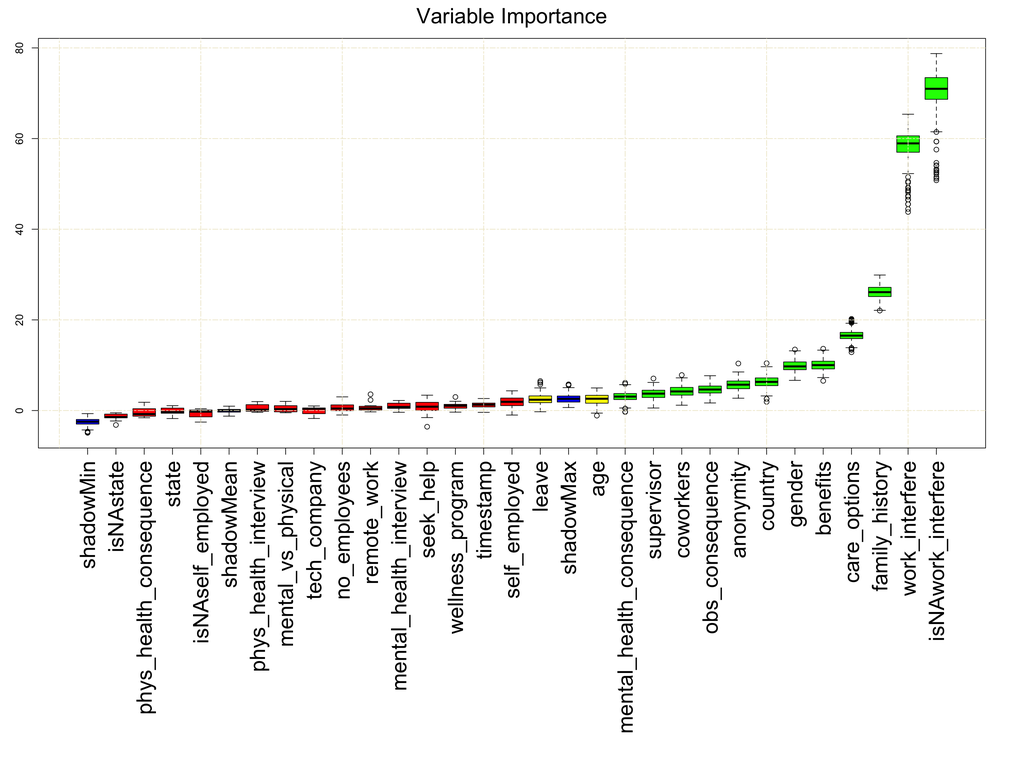

```r
{
    par(mar = c(25, 3, 3, 3))
    plot(boruta.df, xlab = "", xaxt = "n")
    grid (NULL,NULL, lty = 6, col = "cornsilk2")
    lz <- lapply(1:ncol(boruta.df$ImpHistory), function(i) boruta.df$ImpHistory[is.finite(boruta.df$ImpHistory[,i]),i])
    names(lz) <- colnames(boruta.df$ImpHistory)
    Labels    <- sort(sapply(lz, median))
    axis(side = 1, las = 2, labels = names(Labels), at = 1:ncol(boruta.df$ImpHistory), cex.axis = 2)
    mtext("Variable Importance", side = 3, line = 1, cex = 2)
}
```

Here green whisker plots mark variables that should be taken into the model.

- Yellow variables are tentative variables.
- Read variables are unimportant.
- Blue variables are shadow metrics.

## Feature dependence

```r
# TODO: use only not rejected features
rejected = boruta.df$finalDecision == "Rejected"
names_to_select = boruta.df$finalDecision[!rejected] %>%
    unlist() %>%
    names()

df = df %>%
    select(treatment, all_of(names_to_select))

df %>% str(max.level=2)
```

```
## tibble [1,251 x 15] (S3: tbl_df/tbl/data.frame)
##  $ treatment                : Factor w/ 2 levels "No","Yes": 2 1 1 2 1 1 2 1 2 1 ...
##  $ country                  : Factor w/ 48 levels "Australia","Austria",..: 46 46 8 45 46 46 46 8 46 8 ...
##  $ age                      : num [1:1251] 37 44 32 31 31 33 35 39 42 23 ...
##  $ gender                   : Factor w/ 3 levels "confusion","female",..: 2 3 3 3 3 3 2 3 2 3 ...
##  $ family_history           : Factor w/ 2 levels "No","Yes": 1 1 1 2 1 2 2 1 2 1 ...
##  $ work_interfere           : Factor w/ 4 levels "Never","Often",..: 2 3 3 2 1 4 4 1 4 1 ...
##  $ benefits                 : Factor w/ 3 levels "Don't know","No",..: 3 1 2 2 3 3 2 2 3 1 ...
##  $ care_options             : Factor w/ 3 levels "No","Not sure",..: 2 1 1 3 1 2 1 3 3 1 ...
##  $ anonymity                : Factor w/ 3 levels "Don't know","No",..: 3 1 1 2 1 1 2 3 2 1 ...
##  $ leave                    : Factor w/ 5 levels "Don't know","Somewhat difficult",..: 3 1 2 2 1 1 2 1 4 1 ...
##  $ mental_health_consequence: Factor w/ 3 levels "Maybe","No","Yes": 2 1 2 3 2 2 1 2 1 2 ...
##  $ coworkers                : Factor w/ 3 levels "No","Some of them",..: 2 1 3 2 2 3 2 1 3 3 ...
##  $ supervisor               : Factor w/ 3 levels "No","Some of them",..: 3 1 3 1 3 3 1 1 3 3 ...
##  $ obs_consequence          : Factor w/ 2 levels "No","Yes": 1 1 1 2 1 1 1 1 1 1 ...
##  $ isNAwork_interfere       : Factor w/ 2 levels "no","yes": 1 1 1 1 1 1 1 1 1 1 ...
```

If absolute dependence between features close to 0.9 one of those features should be removed. It can seen on the plot below.

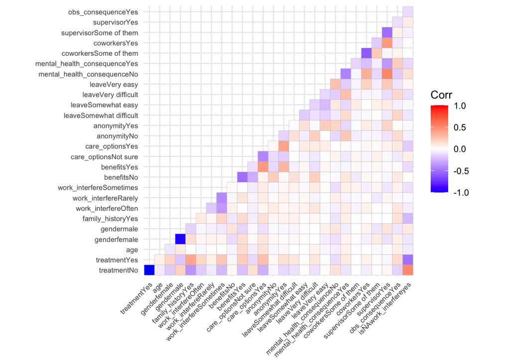

```r
library(ggcorrplot)
model.matrix(~0+., data=df %>% select(-country)) %>%
  cor(use="pairwise.complete.obs") %>%
  ggcorrplot(show.diag = F, type="lower",
             lab=FALSE, lab_size=1, tl.cex=7,
  tl.srt=45)
```

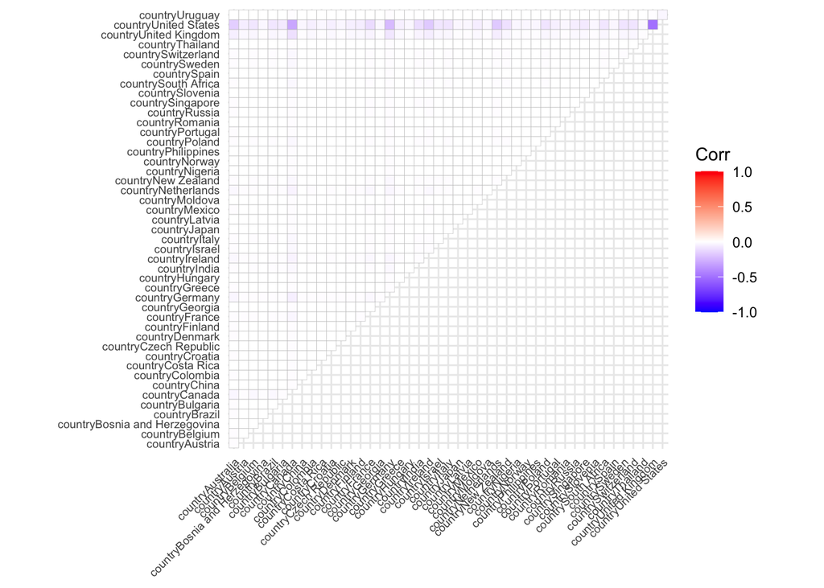

```r
model.matrix(~0+., data=df %>% select(country)) %>%
  cor(use="pairwise.complete.obs") %>%
  ggcorrplot(show.diag = F, type="upper",
             lab=FALSE, lab_size=1, tl.cex=7,
  tl.srt=45)
```

Here `country` feature and the rest features were separated to show these areas more closely. However there is no correlation between `country` and the rest so ploting those together wouldn’t make much sense.

You could notice strong correlation between `treatmentNo` and `treatmentYes` as well as `genderfemale` and `gendermale`. Because these variables are complementary.

At the there no evidence to exclude any variables.

## Model building

Is it possible to build any ML model based on those feature to evaluate the risk of mental health problems?

Before building any model we should split original dataset into training and testing.

```r
library(tidymodels)

df %<>% mutate(treatment = as.character(treatment)) # to make it work

set.seed(0)
df_split <- initial_split(df, prop=4/5)
df_train <- training(df_split)
df_test  <- testing (df_split)

df_cv <- vfold_cv(df_train, strata=treatment, v=5)
```

### Random Forest Model

Classical approach. It is alway a good baseline.

```r
df %>% glimpse()
```

```
## Rows: 1,251
## Columns: 15
## $ treatment                 <chr> "Yes", "No", "No", "Yes", "No", "No", "Ye...
## $ country                   <fct> United States, United States, Canada, Uni...
## $ age                       <dbl> 37, 44, 32, 31, 31, 33, 35, 39, 42, 23, 3...
## $ gender                    <fct> female, male, male, male, male, male, fem...
## $ family_history            <fct> No, No, No, Yes, No, Yes, Yes, No, Yes, N...
## $ work_interfere            <fct> Often, Rarely, Rarely, Often, Never, Some...
## $ benefits                  <fct> Yes, Don't know, No, No, Yes, Yes, No, No...
## $ care_options              <fct> Not sure, No, No, Yes, No, Not sure, No, ...
## $ anonymity                 <fct> Yes, Don't know, Don't know, No, Don't kn...
## $ leave                     <fct> Somewhat easy, Don't know, Somewhat diffi...
## $ mental_health_consequence <fct> No, Maybe, No, Yes, No, No, Maybe, No, Ma...
## $ coworkers                 <fct> Some of them, No, Yes, Some of them, Some...
## $ supervisor                <fct> Yes, No, Yes, No, Yes, Yes, No, No, Yes, ...
## $ obs_consequence           <fct> No, No, No, Yes, No, No, No, No, No, No, ...
## $ isNAwork_interfere        <fct> no, no, no, no, no, no, no, no, no, no, n...
```

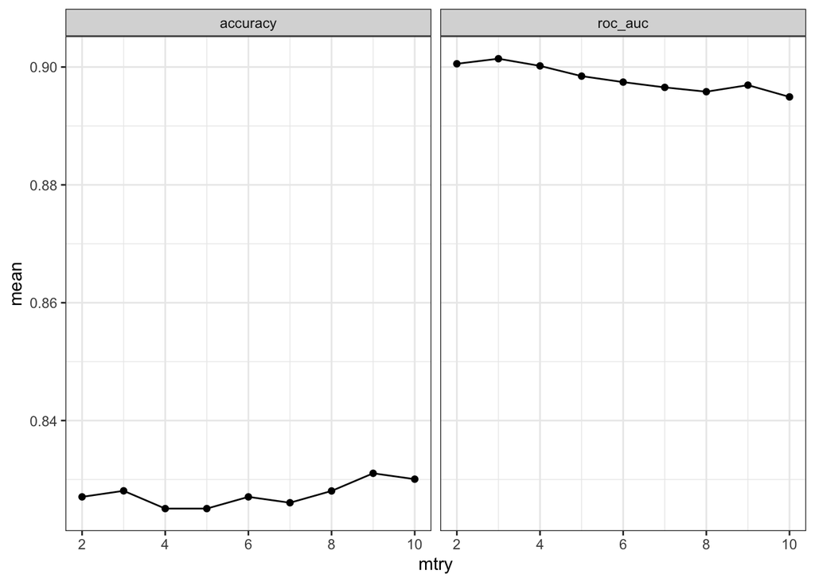

```r
{ # random forest model
    rf_recipe <- df %>%
        recipe(treatment ~ .)

    rf_model <- rand_forest() %>%
        set_args(mtry = tune()) %>%
        set_engine("ranger", importance = "impurity") %>%
        set_mode("classification")

    rf_workflow <- workflow() %>%
        add_recipe(rf_recipe) %>%
        add_model(rf_model)

    rf_grid  <- expand.grid(mtry=2:10)

    rf_tune_results <- rf_workflow %>%
        tune_grid(resamples = df_cv,
                  grid      = rf_grid,
                  control   = control_grid(save_pred = TRUE, verbose = FALSE),
                  metrics   = metric_set(accuracy, roc_auc))

}


{ # plot the penalty plot
    rf_plot  <-
        rf_tune_results %>%
        collect_metrics() %>%
        ggplot(aes(x = mtry, y = mean)) +
        geom_point() +
        geom_line() +
        facet_wrap(~.metric) +
        theme_bw()

    rf_plot

}
```

```r
{ # choosing the best parameter and building the final model
    param_final  <- rf_tune_results %>%
        select_best(metric = "roc_auc")

    rf_fit  <- rf_workflow %>%
        finalize_workflow(param_final) %>%
        last_fit(df_split)

}

{ # calculate AUC
    roc_obj = rf_fit %>%
        collect_predictions() %>%
        pROC::roc(treatment, .pred_Yes)
    auc_metric = pROC::auc(roc_obj)[[1]]


}
```

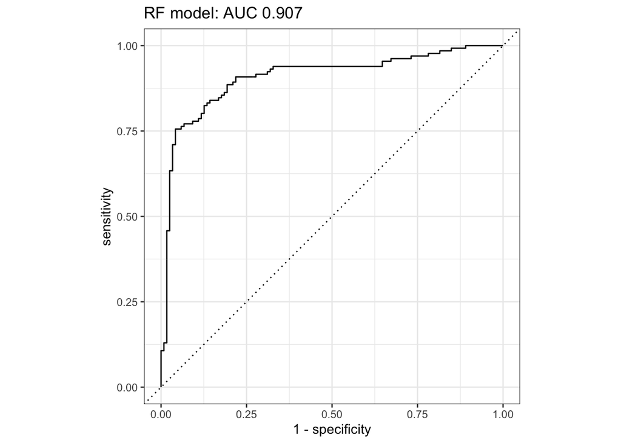

```r
{ # draw ROC
    rf_auc <- rf_fit %>%
        collect_predictions() %>%
        roc_curve(treatment, .pred_No) %>%
        mutate(model = "Random Forest")
    rf_roc_plot <- autoplot(rf_auc) +
        ggtitle(paste0(c("RF model: AUC", round(auc_metric, 3)), collapse=" "))

    rf_roc_plot
}
```

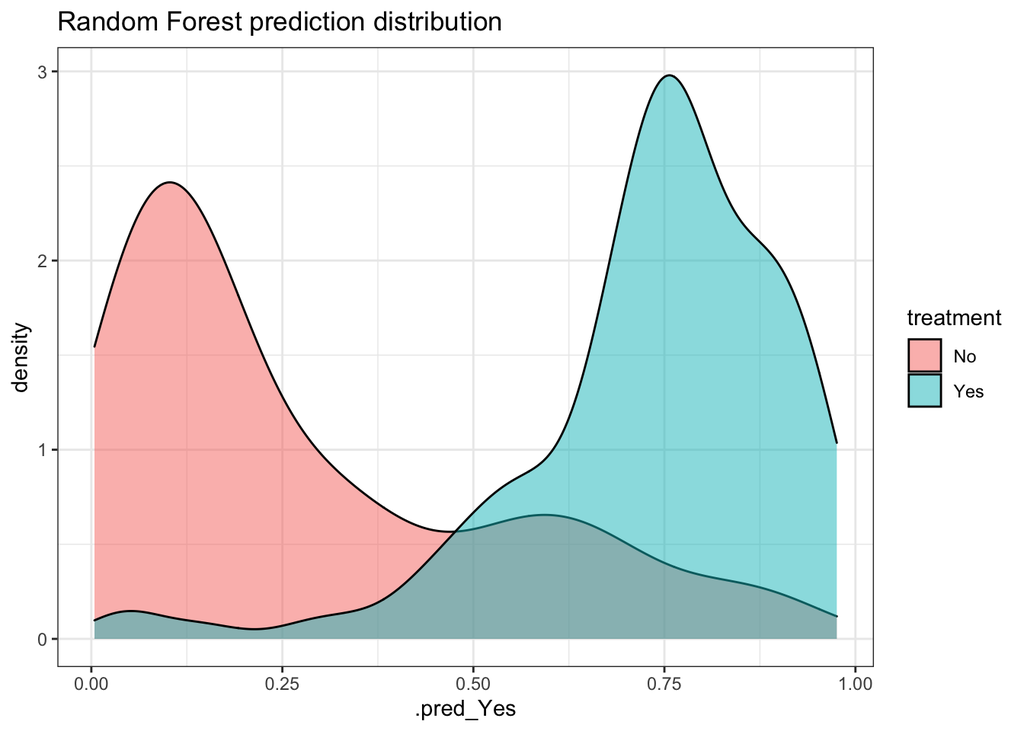

```r
{ # validation
    test_performance <- rf_fit %>%
        collect_metrics(); test_performance

    test_predictions <- rf_fit %>%
        collect_predictions()

    test_predictions %>% conf_mat(truth = treatment, estimate = .pred_class)

    test_predictions %>%
        ggplot() +
        geom_density(aes(x = .pred_Yes, fill = treatment), alpha=0.5) +
        theme_bw() +
        ggtitle("Random Forest prediction distribution")

}
```

### SVM model

```r
{ # svm model
    svm_recipe <- df %>%
        recipe(treatment ~ .)  %>%
        step_zv(all_predictors()) #%>%
#         step_lincomb(all_numeric())

    svm_model <-
        svm_rbf(cost = tune(), rbf_sigma = tune()) %>%
        set_mode("classification") %>%
        set_engine("kernlab")

    svm_workflow <- workflow() %>%
        add_recipe(svm_recipe) %>%
        add_model(svm_model)

    ctrl <- control_grid(verbose = FALSE, save_pred = TRUE)

    svm_tune_results <- svm_workflow %>%
      tune_grid(resamples = df_cv,
        metrics = metric_set(accuracy, roc_auc),
        control = ctrl
      )

}
```

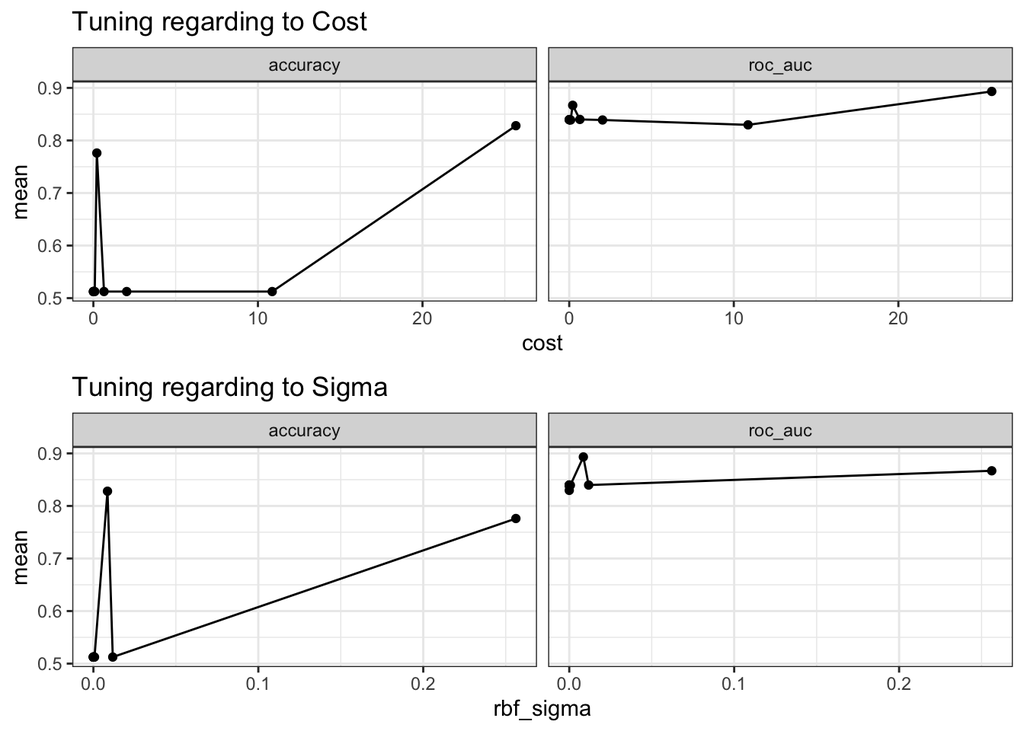

```r
{ # plot the penalty plot
    svm_plot_cost  <-
        svm_tune_results %>%
        collect_metrics() %>%
#         filter(.metric == "roc_auc") %>%
        ggplot(aes(x = cost, y = mean)) +
        geom_point() +
        geom_line() +
        facet_wrap(~.metric) +
#         ylab("AUC the ROC Curve") +
        theme_bw() +
        ggtitle("Tuning regarding to Cost")

    svm_plot_sigma  <-
        svm_tune_results %>%
        collect_metrics() %>%
#         filter(.metric == "roc_auc") %>%
        ggplot(aes(x = rbf_sigma, y = mean)) +
        geom_point() +
        geom_line() +
        facet_wrap(~.metric) +
#         ylab("AUC the ROC Curve") +
        theme_bw() +
        ggtitle("Tuning regarding to Sigma")

    gridExtra::grid.arrange(svm_plot_cost, svm_plot_sigma, nrow = 2)

}
```

```r
{ # choosing the best parameter and building the final model
    param_final  <- svm_tune_results %>%
        select_best(metric = "roc_auc")

    svm_fit  <- svm_workflow %>%
        finalize_workflow(param_final) %>%
        last_fit(df_split)

}

{ # calculate AUC
    install.packages("pROC")
    roc_obj = svm_tune_results %>%
        collect_predictions(parameters = param_final)  %>%
        pROC::roc(treatment, .pred_Yes)
    auc_metric = pROC::auc(roc_obj)[[1]]


}
```

[output not shown]

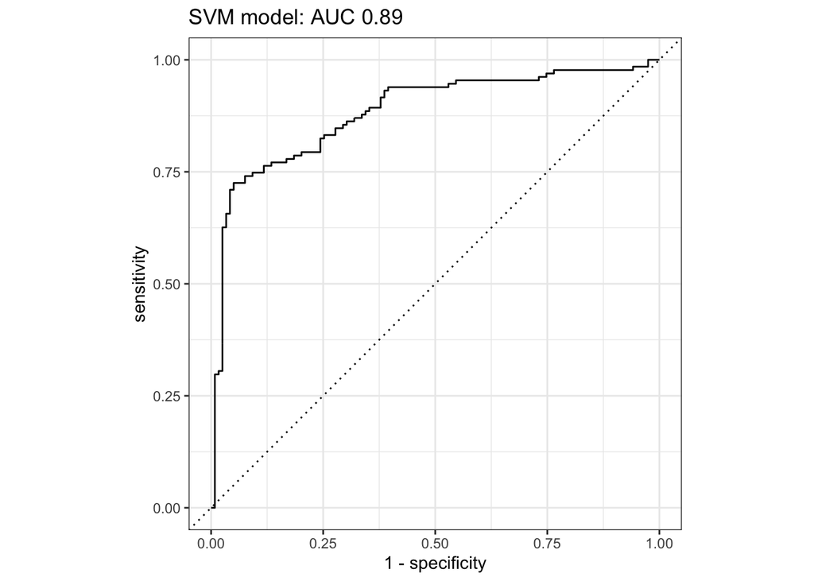

```r
{ # draw ROC
    svm_auc <- svm_fit %>%
        collect_predictions() %>%
        roc_curve(treatment, .pred_No) %>%
        mutate(model = "Random Forest")
    roc_plot <- autoplot(svm_auc) +
        ggtitle(paste0(c("SVM model: AUC", round(auc_metric, 3)), collapse=" "))

    roc_plot
}
```

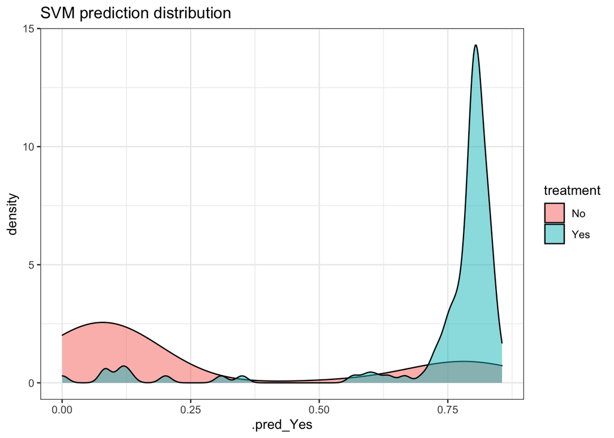

```r
{ # validation
    test_performance <- svm_fit %>%
        collect_metrics(); test_performance

    test_predictions <- svm_fit %>%
        collect_predictions(); test_predictions

    test_predictions %>% conf_mat(truth = treatment, estimate = .pred_class)

    test_predictions %>%
        ggplot() +
        geom_density(aes(x = .pred_Yes, fill = treatment), alpha=0.5) +
        theme_bw() +
        ggtitle("SVM prediction distribution")



}
```

You can see that RF model and SVM model have close AUC ROC and accuracy. But the prediction distribution for SVM looks a bit more sparse, so out of these 2 models we will proceed with RF model.

### Random Forest testing

```r
{ # Testing
    treatment_fit <- fit(rf_workflow, data=df_train)

    predicted = predict(treatment_fit, df_test)
    accuracy = sum(df_test$treatment == predicted)/nrow(predicted)
    accuracy

}
```

```
## [1] 0.844
```